# 2014 Seagrass macroinvertebrate diversity and abundance

Zach Monteith

Tue Mar 15 11:24:24 2016

# Macro invertebrate diversity and abundance

This file summarizes macro invertebrate (ie. crabs, seastars, nudibranchs) data from sea grass monitoring transects. It was created by ZLM Nov 2015 (based on inverts.R by MV) for analysis of 2014 and 2015 monitoring data, but with the goal of being generalized to use for future years data as well. Created by ZLM Nov 2015, it is based on inverts.R goal: grazer abundance/msq ## Setup Remove all objects for a clean start!

**NOTE:** this command will clear all your objects, don’t run it if you have any unsaved objects you would like to keep.

**NOTE2:** this command should only be used when running this script directly; if you are sourcing multiple scripts including this one, make sure this is commented out, otherwise it will cause problems!

```r
# rm(list = ls())
```

Next, install packages that will be used for this script. Note that this command is currently commented out, if you do not have these packages, make sure you remove the hash and install them!

```r
# install.packages(c("ggplot2", "dplyr", "magrittr))
```

Now the packages are installed, make sure to load them

```r
lapply(c("ggplot2", "dplyr", "magrittr"), library, character.only = T)
```

This script uses functions that are stored in a separate script, so we’ll source that now.

```r
source("invert.functions.R")
```

Now we’re ready to load the invert data.

**NOTE:** Make sure you change the path to match where you have your csv’s stored, otherwise this won’t work!

```r
invert <- read.csv("../../Google Drive/Hakai SEA 2014/R files/csv files/Inverts.csv", header = T)
```

Now have a quick check of the data structure and format

```r
glimpse(invert)  # glimpse() is similar to structure, but tidier
```

```
## Observations: 2,024
## Variables: 13
## $ Date       (fctr) 23/07/2014, 23/07/2014, 23/07/2014, 23/07/2014, 23...
## $ Site       (fctr) Lower_Choked, Lower_Choked, Lower_Choked, Lower_Ch...
## $ Site_ID    (fctr) LC, LC, LC, LC, LC, LC, LC, LC, LC, LC, LC, LC, LC...
## $ Diver      (fctr) OP, OP, OP, OP, OP, OP, OP, OP, OP, OP, OP, OP, OP...
## $ Mode       (fctr) SCUBA, SCUBA, SCUBA, SCUBA, SCUBA, SCUBA, SCUBA, S...
## $ Transect   (int) 1, 1, 1, 1, 1, 1, 1, 1, 1, 1, 1, 1, 1, 1, 1, 1, 1, ...
## $ Depth_m    (dbl) 2.6, 2.6, 2.6, 2.6, 2.6, 2.6, 2.6, 2.6, 2.6, 2.6, 2...
## $ Time_Start (fctr) 9:31:00AM, 9:31:00AM, 9:31:00AM, 9:31:00AM, 9:31:0...
## $ Species    (fctr) Pycnopodia_helianthoides, Pycnopodia_helianthoides...
## $ Common     (fctr) Sunflower_Star, Sunflower_Star, Sunflower_Star, Su...
## $ Length_cm  (int) 20, 18, 38, 12, 23, 46, 50, 7, 52, 8, 19, 23, 23, 3...
## $ Estimate   (int) 1, 1, 1, 1, 1, 1, 1, 1, 1, 1, 1, 1, 1, 1, 1, 1, 1, ...
## $ Notes      (fctr) , , , , , , , , , , , , , , , , , , , , , , , ,
```

```r
head(invert)
```

```
##         Date         Site Site_ID Diver  Mode Transect Depth_m Time_Start
## 1 23/07/2014 Lower_Choked      LC    OP SCUBA        1     2.6  9:31:00AM
## 2 23/07/2014 Lower_Choked      LC    OP SCUBA        1     2.6  9:31:00AM
## 3 23/07/2014 Lower_Choked      LC    OP SCUBA        1     2.6  9:31:00AM
## 4 23/07/2014 Lower_Choked      LC    OP SCUBA        1     2.6  9:31:00AM
## 5 23/07/2014 Lower_Choked      LC    OP SCUBA        1     2.6  9:31:00AM
## 6 23/07/2014 Lower_Choked      LC    OP SCUBA        1     2.6  9:31:00AM
##                    Species         Common Length_cm Estimate Notes
## 1 Pycnopodia_helianthoides Sunflower_Star        20        1
## 2 Pycnopodia_helianthoides Sunflower_Star        18        1
## 3 Pycnopodia_helianthoides Sunflower_Star        38        1
## 4 Pycnopodia_helianthoides Sunflower_Star        12        1
## 5 Pycnopodia_helianthoides Sunflower_Star        23        1
## 6 Pycnopodia_helianthoides Sunflower_Star        46        1
```

## Formatting

Before summarizing and making figures we will reformat/add some factors to match with the other parts of the monitoring dataset, before printing a table with counts by site, ### Renaming and adding factors The variable `Site_ID` is currently formatted inconsistently, and the `region`,variables is missing; we’ll fix these using `dplyr::mutate`, and some `ifelse` statements.

```r
inverts <- invert %>%  # with growth df...
  mutate(site_id = as.factor(ifelse(Site_ID == "SC", "CS",
                          ifelse(Site_ID == "LC", "CL",
                                 ifelse(Site_ID == "NT", "TN",
                                        as.character(Site_ID))))),
         site    = ifelse(site_id == "CL", "Choked Lower",
                             ifelse(site_id == "CS", "Choked Sandspit",
                                    ifelse(site_id == "TB", "Triquet Bay",
                                           ifelse(site_id == "TN", "Triquet North",
                                                  ifelse(site_id == "GW", "Goose Southwest",
                                                         ifelse(site_id == "GE", "Goose Southeast",
                                                                ifelse(site_id == "MS", "McMullin South",
                                                                       ifelse(site_id == "MN", "McMullin North",
                                                                              NA)))))))),
         region = as.factor(ifelse(site_id == "CS" | site_id == "CL", "Choked",
                         ifelse(site_id == "TB" | site_id == "TN", "Triquet",
                                ifelse(site_id == "GE" | site_id == "GW", "Goose",
                                       "McMullin")))))
```

### Adding absences to the dataset

The in 2014 and 2015 the survey data only includes observations (presence only data). This results in biased abundance estimates; the loop found below goes through each transect, and checks if all the species were observed. If a species were not observed on a transect, a ‘zero’ observation will be added in. This way, abundance is not conditional on observation, and should no longer be biased.

```r
# make species list
inverts.spp <- subset(unique(inverts$Common), !grepl("unknown", unique(inverts$Common)))
# create unique transect factor
inverts$unique.tran <- with(inverts, as.factor(paste(site, Transect, Time_Start, Diver, sep = "::")))
uniqueTran <- unique(inverts$unique.tran)

# for each site...
for (i in 1:length(uniqueTran)) {
  tmp.invert.tran <-
    subset(inverts, unique.tran %in% uniqueTran[i])

  tmp.metadata <-
    tmp.invert.tran %>%
    # group_by(year, day, region, site, site_id, Transect, survey, diver, mode,
    #          tran_length, tran_type, time_start, time_end, tide_start,
    #          tide_end, vis_ft, current_cat, depth_m, unique.tran) %>%
    group_by(Date, Site, Site_ID, Diver, Mode, Transect, Depth_m, Time_Start, site_id,
             site, region, unique.tran) %>%
    summarise()

  tmp.metadata$Species   <- NA
  tmp.metadata$Common    <- NA
  tmp.metadata$Length_cm <- NA
  tmp.metadata$Estimate  <- 0
  tmp.metadata$Notes     <- "implicit zero"

  # for each invert species...
  for (j in 1:length(inverts.spp)) {
    # if invert species j does not show up in any row, add new row
    # if (length(grep(paste0("^", inverts.spp[j], "$") tmp.invert.tran$Common)) == 0) {
    if (length(which(tmp.invert.tran$Common == inverts.spp[j])) == 0) {

      tmp.metadata$Common <- inverts.spp[j]
      inverts <- rbind(inverts, tmp.metadata)
    } else { # if invert species j is present, move on
      next
    }
  }
}
```

### Defining taxonomic subsets

Here we’ll subset the invertebrate dataset into a couple smaller groups of interest: crabs, nudibranchs, seastars, and everything else, for a more indepth look.

```r
invert.crab <- subset(inverts, Common %in% c("Cryptic_Kelp_crab",
                                            "Kelp_crab",
                                            "Helmet_Crab",
                                            "Red_Rock_Crab",
                                            "Dungeness",
                                            "Furrowed_crab"))

invert.nudi <- subset(inverts, Common %in% c("Hooded_Nudibranch",
                                            "Frosted_nudibranch",
                                            "Leopard_nudibranch",
                                            "Opalescent_Nudibranch",
                                            "Orange_amd_white_tipped_nudi"))

invert.star <- subset(inverts, Common %in% c("Sunflower_Star",
                                            "Leather_Star",
                                            "Giant_Pink_Star",
                                            "Mottled_Star"))

# invert.various <- subset(inverts, Common %in% c("Giant_Green_Anemone",
#                                                "Moonsnail",
#                                                "Painted_Anemone",
#                                                "Red Urchin",
#                                                "Sea_Cucumber",
#                                                "Sea_Hare",
#                                                "Seagrass_Isopod",
#                                                "Shrimp",
#                                                "Stubby_Rose_Anemone",
#                                                "Tube-Dwelling_Anemone"))
```

## Frequency table

Now that all the `site_id`’s are formatted correctly, this is a good time to generate a frequency table. This will give a nice overview of how many of each species were observed, and where.

```r
(invert.count <- with(inverts, xtabs(Estimate ~ Common + site_id)))
```

```
##                               site_id
## Common                          CL  CS  GE  GW  MN  MS  TB  TN
##   Bloodstar                      0   0   1   0   0   0   0   0
##   Cryptic_Kelp_crab             71  77  97  57 136 144 141 104
##   Dungeness                      2   0   0   0   0   0   0   0
##   Frosted_nudibranch             1   1   0   0   0   0   0   0
##   Furrowed_crab                  1   0   0   0   0   0   0   0
##   Giant_Green_Anemone            1   0   0   0   0   0   0   0
##   Giant_Pink_Star                0   0   1   1   0   0   0   0
##   Helmet_Crab                    0   0   2   1   0   0   0   0
##   Hooded_Nudibranch             22   0   2   0 106 215 347   8
##   Kelp_crab                      4   8   2   6  18  24   7   8
##   Leather_Star                   2   0  36   0   0   1   0   1
##   Leopard_nudibranch             0   0   0   1   0   0   0   0
##   Moonsnail                      2   0   0   0   0   0   3   0
##   Mottled_Star                   0   0   0   0   0   0   0   1
##   Opalescent_Nudibranch          0   1   0   0   0   0   2   0
##   Orange_amd_white_tipped_nudi   0   0   0   0   0   0   1   0
##   Painted_Anemone                0   0   1   0   0   0   0   0
##   Red_Rock_Crab                  0   0   2   0   0   0   1   0
##   Red_Urchin                     0   0   0   2   0   0   0   0
##   Sea_Cucumber                   0   0   0   1   0   0   0   0
##   Sea_Hare                       0   0   0   0   0 160  12   0
##   Seagrass_Isopod                2  12   0   0   0   2   1   0
##   Shrimp                         2   0   0   0   0  37   0   0
##   Stubby_Rose_Anemone            0   0   0   0   0   0   0   1
##   Sunflower_Star                41  33  13   8   5   5   4  11
##   Tube-Dwelling_Anemone          0   0   0   0   0   0   1   0
```

Now save the table for later use.

```r
write.csv(invert.count, "Invertebrate_Summary.csv")
```

## Summaries

This section will calculate abundance, richness, and diversity (using H`, the [Shannon Index](https://en.wikipedia.org/wiki/Diversity_index#Shannon_index)), by site, and by region. This is done first for all invertebrates, then for the taxonomic subsets we specified in the formatting section.

### All invertebrates

```r
(invert.summary.site   <- MakeInvertSummary(inverts, site))
```

```
##     region            site mean.abund  se.abund mean.H.prime se.H.prime n
## 1   Choked    Choked Lower   50.33333  2.962731    1.3567137 0.09383918 3
## 2   Choked Choked Sandspit   44.00000 12.423097    1.1004516 0.11824131 3
## 3    Goose Goose Southeast   52.33333  4.630815    1.0494801 0.13296025 3
## 4    Goose Goose Southwest   25.66667  8.685876    0.8995044 0.13461877 3
## 5 McMullin  McMullin North   88.33333 11.921036    0.7797294 0.03694050 3
## 6 McMullin  McMullin South  196.00000 55.560778    1.2473716 0.03259985 3
## 7  Triquet     Triquet Bay  173.33333 32.415703    0.9184997 0.14724863 3
## 8  Triquet   Triquet North   44.66667  6.359595    0.7798158 0.23364568 3
##   rich
## 1   12
## 2    6
## 3   10
## 4    8
## 5    4
## 6    8
## 7   11
## 8    7
```

```r
write.csv(invert.summary.site, "summaries/invert.abund.site.2014.csv")
(invert.summary.region <- MakeInvertSummary(inverts))
```

```
##     region mean.abund  se.abund mean.H.prime se.H.prime n rich
## 1   Choked   47.16667  5.884537    1.2285826 0.08854871 6   13
## 2    Goose   39.00000  7.411702    0.9744923 0.09102068 6   13
## 3 McMullin  142.16667 35.006111    1.0135505 0.10686408 6    8
## 4  Triquet  109.00000 32.341923    0.8491577 0.12734266 6   14
```

```r
write.csv(invert.summary.region, "summaries/invert.abund.region.2014.csv")
```

### Crabs only

```r
(crab.summary.site     <- MakeInvertSummary(invert.crab, site))
```

```
##     region            site mean.abund  se.abund mean.H.prime se.H.prime n
## 1   Choked    Choked Lower   26.00000  6.244998    0.3403169 0.10273756 3
## 2   Choked Choked Sandspit   28.33333  9.701088    0.3548562 0.07468033 3
## 3    Goose Goose Southeast   34.33333  7.333333    0.2328780 0.03117407 3
## 4    Goose Goose Southwest   21.33333  8.110350    0.3576257 0.19285425 3
## 5 McMullin  McMullin North   51.33333 11.406626    0.3673665 0.01983540 3
## 6 McMullin  McMullin South   56.00000  5.567764    0.4083235 0.06245255 3
## 7  Triquet     Triquet Bay   49.66667  4.630815    0.2048805 0.08138094 3
## 8  Triquet   Triquet North   37.33333  8.685876    0.2589606 0.07829768 3
##   rich
## 1    4
## 2    2
## 3    4
## 4    3
## 5    2
## 6    2
## 7    3
## 8    2
```

```r
write.csv(crab.summary.site, "summaries/crab.abund.site.2014.csv")
(crab.summary.region   <- MakeInvertSummary(invert.crab))
```

```
##     region mean.abund se.abund mean.H.prime se.H.prime n rich
## 1   Choked   27.16667 5.185985    0.3475866 0.05689465 6    4
## 2    Goose   27.83333 5.688683    0.2952518 0.09171159 6    4
## 3 McMullin   53.66667 5.771578    0.3878450 0.03070223 6    2
## 4  Triquet   43.50000 5.194548    0.2319205 0.05193178 6    3
```

```r
write.csv(crab.summary.region, "summaries/crab.abund.region.2014.csv")
```

### Nudibranchs only

```r
(nudi.summary.site     <- MakeInvertSummary(invert.nudi, site))
```

```
##     region            site  mean.abund   se.abund mean.H.prime se.H.prime
## 1   Choked    Choked Lower   7.6666667  0.8819171   0.11627737 0.11627737
## 2   Choked Choked Sandspit   0.6666667  0.3333333   0.00000000 0.00000000
## 3    Goose Goose Southeast   0.6666667  0.6666667   0.00000000 0.00000000
## 4    Goose Goose Southwest   0.3333333  0.3333333   0.00000000 0.00000000
## 5 McMullin  McMullin North  35.3333333 23.1396725   0.00000000 0.00000000
## 6 McMullin  McMullin South  71.6666667 57.1732261   0.00000000 0.00000000
## 7  Triquet     Triquet Bay 116.6666667 29.0421150   0.07484585 0.07484585
## 8  Triquet   Triquet North   2.6666667  2.1858128   0.00000000 0.00000000
##   n rich
## 1 3    2
## 2 3    2
## 3 3    1
## 4 3    1
## 5 3    1
## 6 3    1
## 7 3    3
## 8 3    1
```

```r
write.csv(nudi.summary.site, "summaries/nudi.abund.site.2014.csv")
(nudi.summary.region   <- MakeInvertSummary(invert.nudi))
```

```
##     region mean.abund  se.abund mean.H.prime se.H.prime n rich
## 1   Choked   4.166667  1.621042   0.05813868 0.05813868 6    3
## 2    Goose   0.500000  0.341565   0.00000000 0.00000000 6    2
## 3 McMullin  53.500000 28.755000   0.00000000 0.00000000 6    1
## 4  Triquet  59.666667 28.625940   0.03742293 0.03742293 6    3
```

```r
write.csv(nudi.summary.region, "summaries/nudi.abund.region.2014.csv")
```

### Seastars only

```r
(star.summary.site     <- MakeInvertSummary(invert.star, site))
```

```
##     region            site mean.abund  se.abund mean.H.prime se.H.prime n
## 1   Choked    Choked Lower  14.333333 3.9299420    0.1572478 0.08394941 3
## 2   Choked Choked Sandspit  11.000000 1.0000000    0.0000000 0.00000000 3
## 3    Goose Goose Southeast  16.666667 4.4095855    0.6411403 0.07116301 3
## 4    Goose Goose Southwest   3.000000 1.1547005    0.0000000 0.00000000 3
## 5 McMullin  McMullin North   1.666667 1.2018504    0.0000000 0.00000000 3
## 6 McMullin  McMullin South   2.000000 0.5773503    0.2121714 0.21217139 3
## 7  Triquet     Triquet Bay   1.333333 0.3333333    0.0000000 0.00000000 3
## 8  Triquet   Triquet North   4.333333 1.4529663    0.3677545 0.20121228 3
##   rich
## 1    2
## 2    1
## 3    3
## 4    2
## 5    1
## 6    2
## 7    1
## 8    3
```

```r
write.csv(star.summary.site, "summaries/star.abund.site.2014.csv")
(star.summary.region   <- MakeInvertSummary(invert.star))
```

```
##     region mean.abund  se.abund mean.H.prime se.H.prime n rich
## 1   Choked  12.666667 1.9607255    0.0786239 0.05143777 6    2
## 2    Goose   9.833333 3.6734785    0.3205701 0.14685325 6    3
## 3 McMullin   1.833333 0.6009252    0.1060857 0.10608569 6    2
## 4  Triquet   2.833333 0.9457507    0.1838772 0.12189932 6    3
```

```r
write.csv(star.summary.region, "summaries/star.abund.region.2014.csv")
```

### Various invertebrates

```r
# var.summary.site      <- MakeInvertSummary(invert.various, site)
# var.summary.region    <- MakeInvertSummary(invert.various)
```

## Figures

### All invertebrates

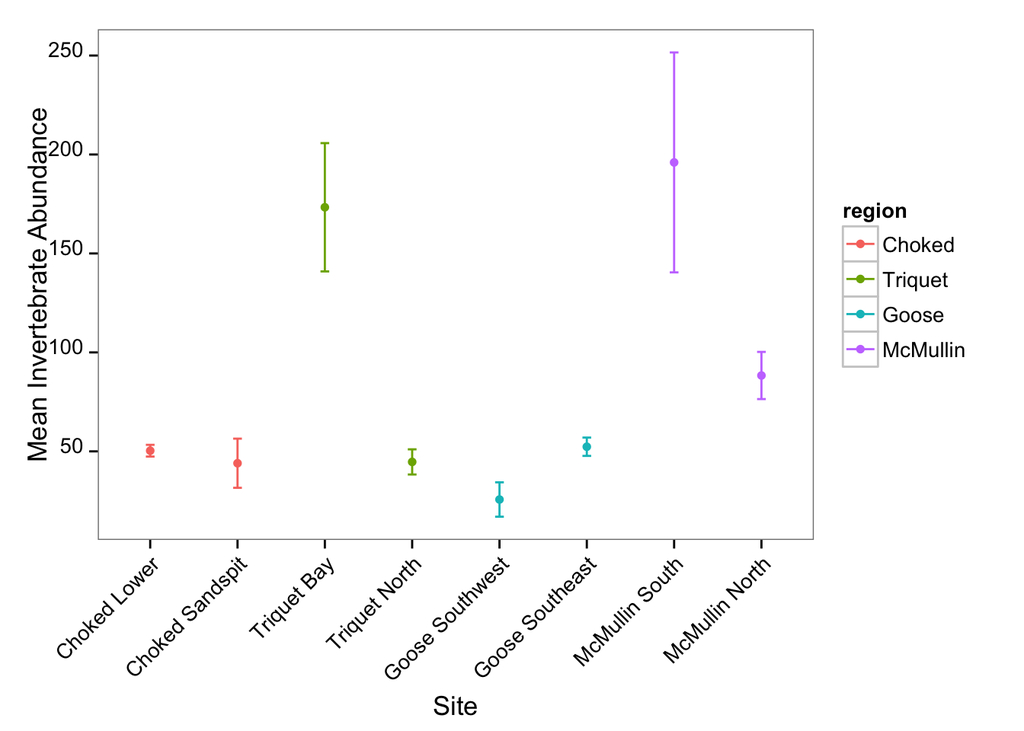

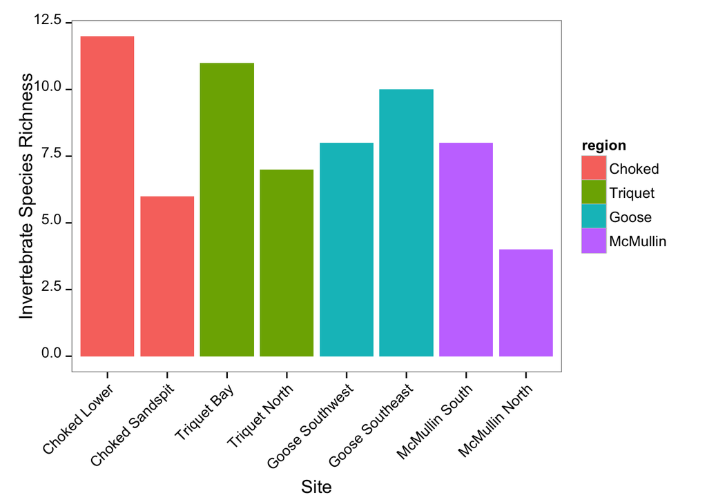

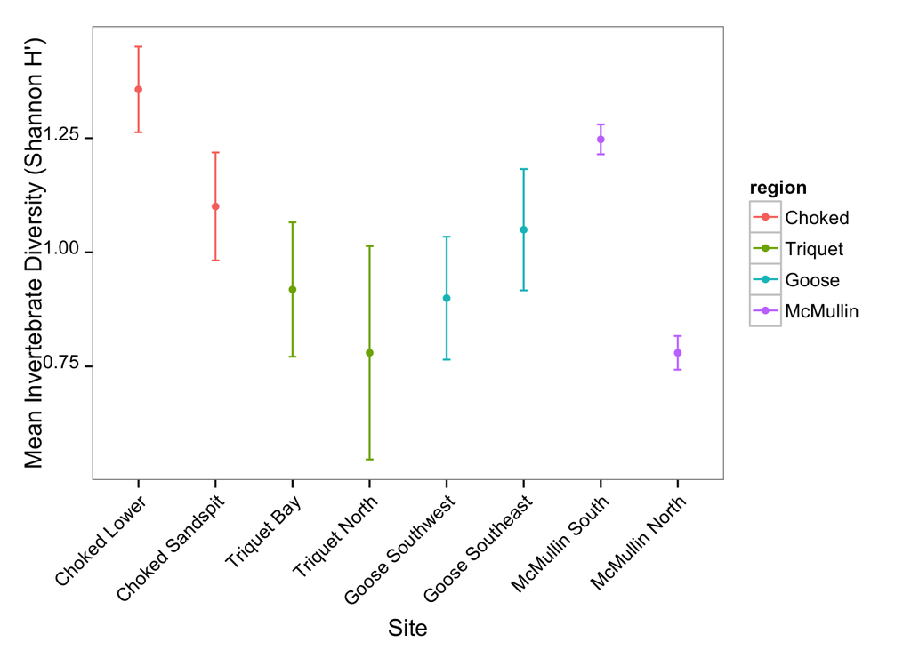

```r
(invert.figs.site   <- MakeInvertFigures(invert.summary.site))
```

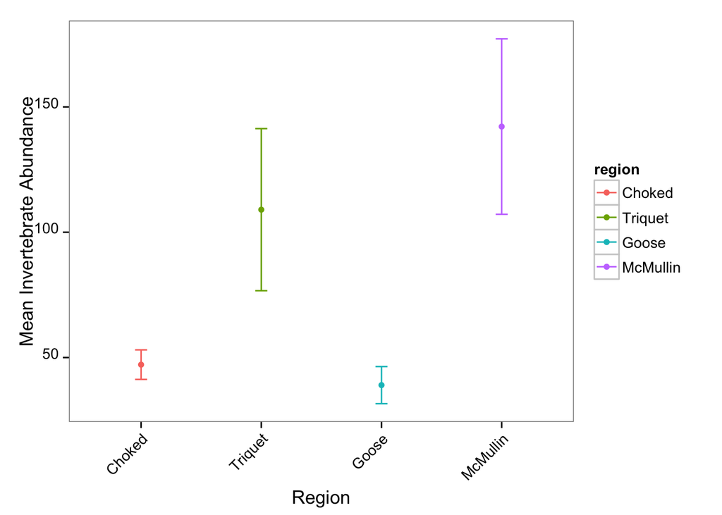

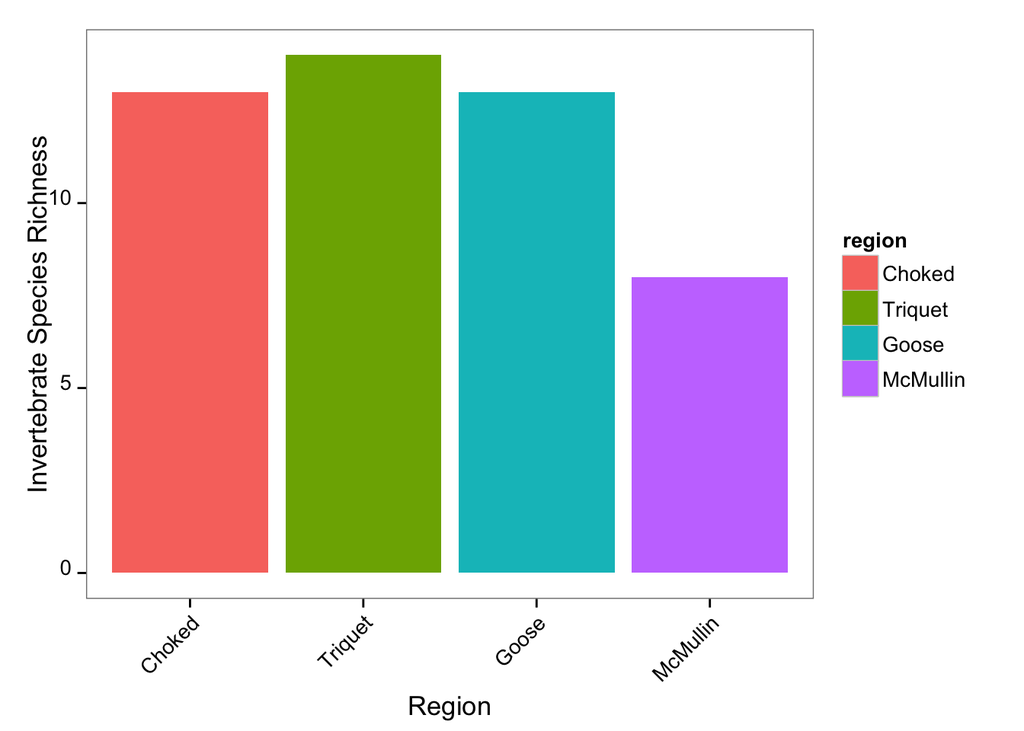

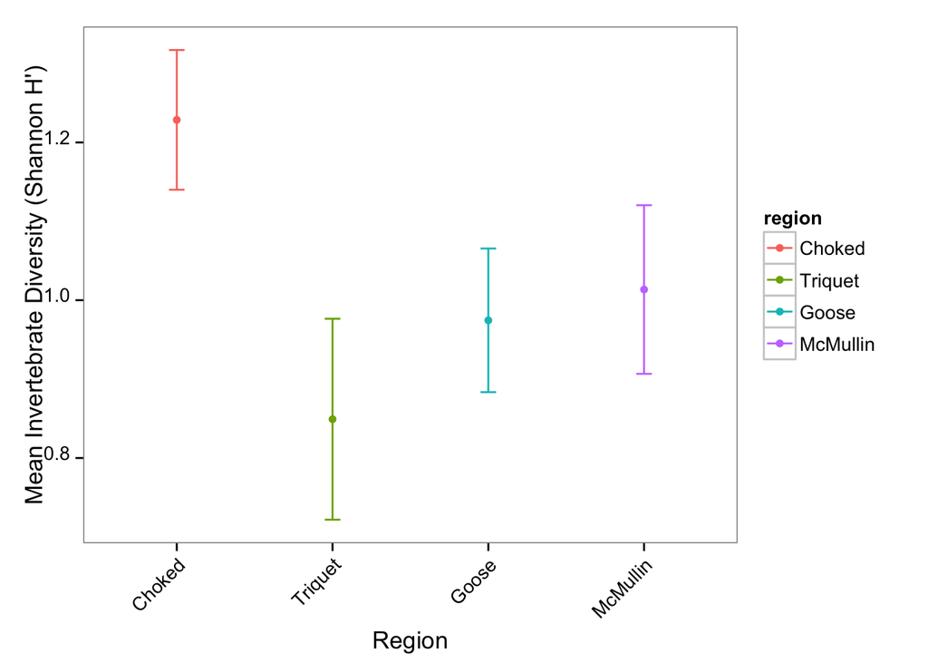

```r
(invert.figs.region <- MakeInvertFigures(invert.summary.region))
```

### Crabs only

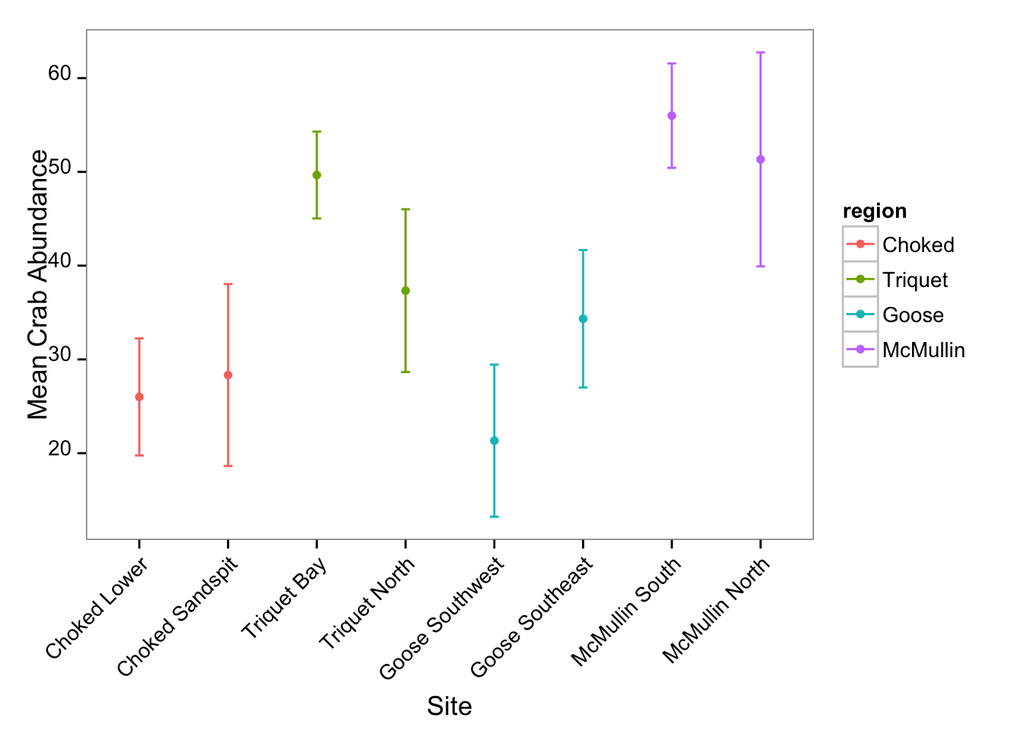

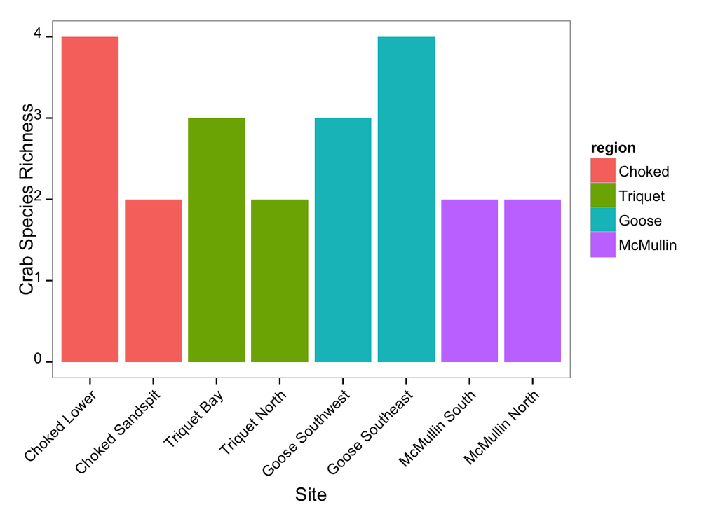

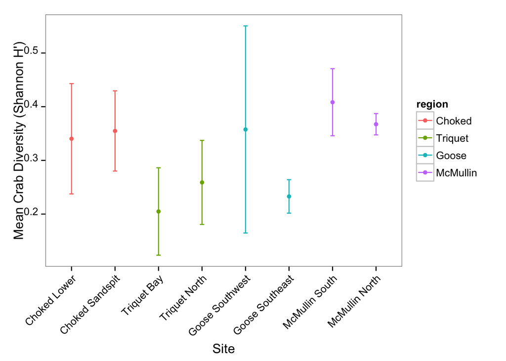

```r
(crab.figs.site     <- MakeInvertFigures(crab.summary.site))
```

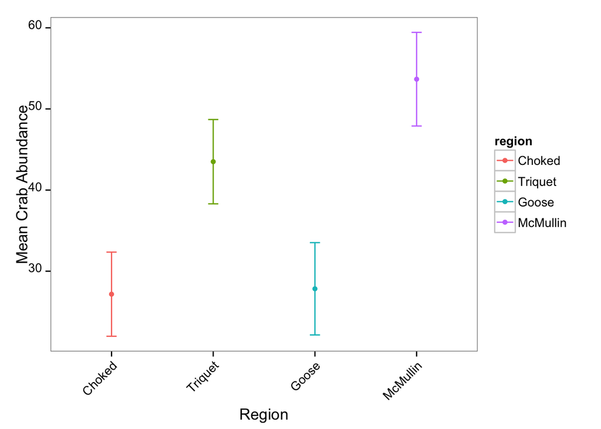

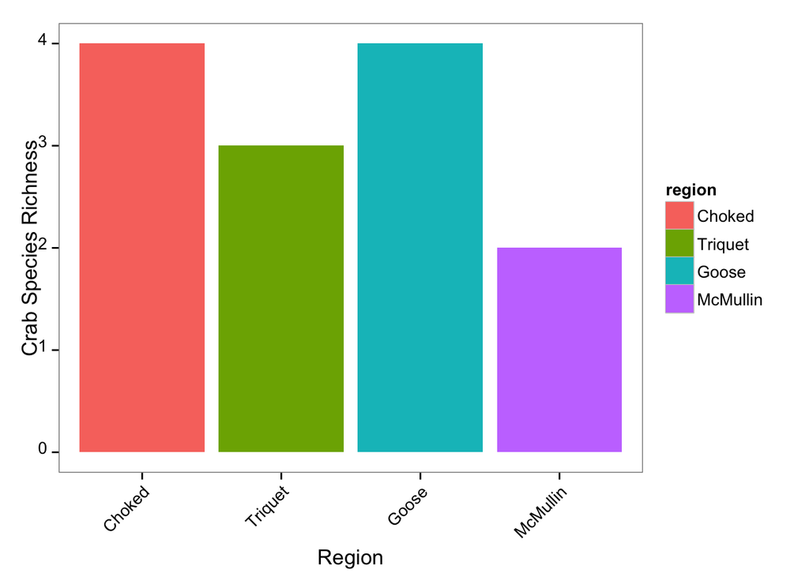

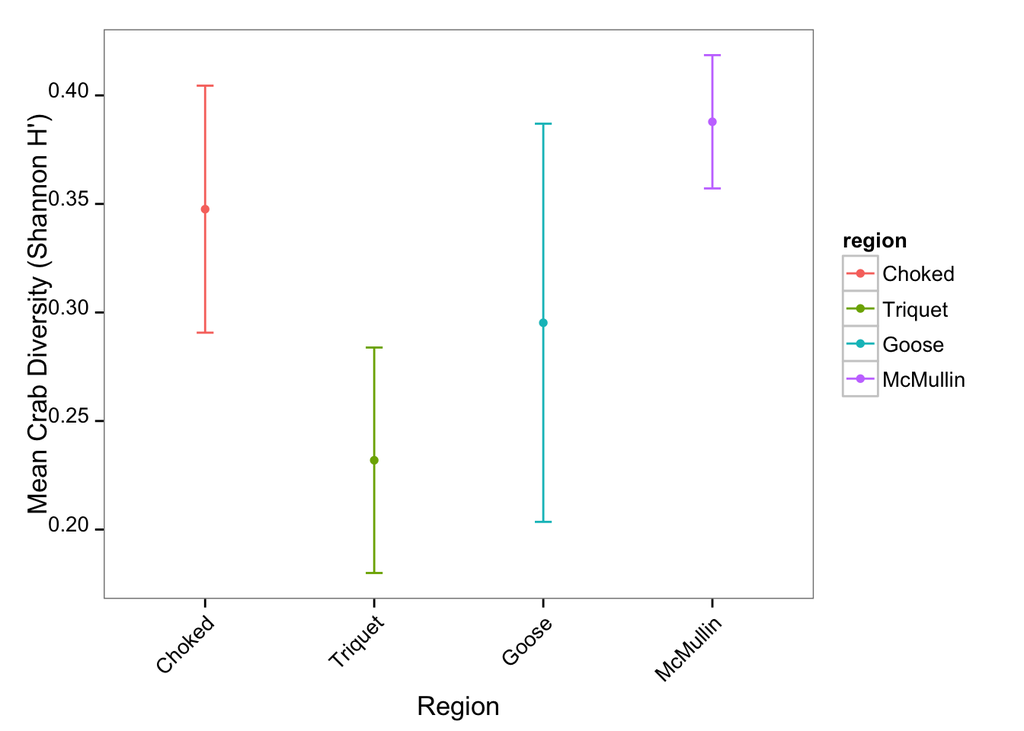

```r
(crab.figs.region   <- MakeInvertFigures(crab.summary.region))
```

### Nudibranchs only

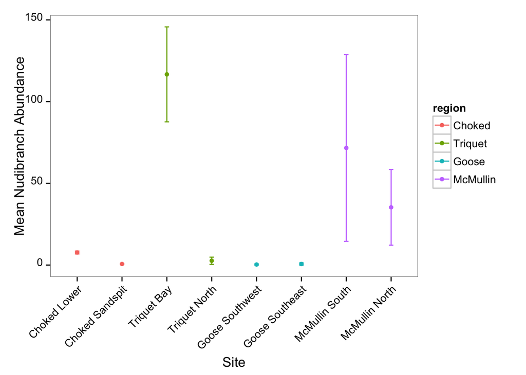

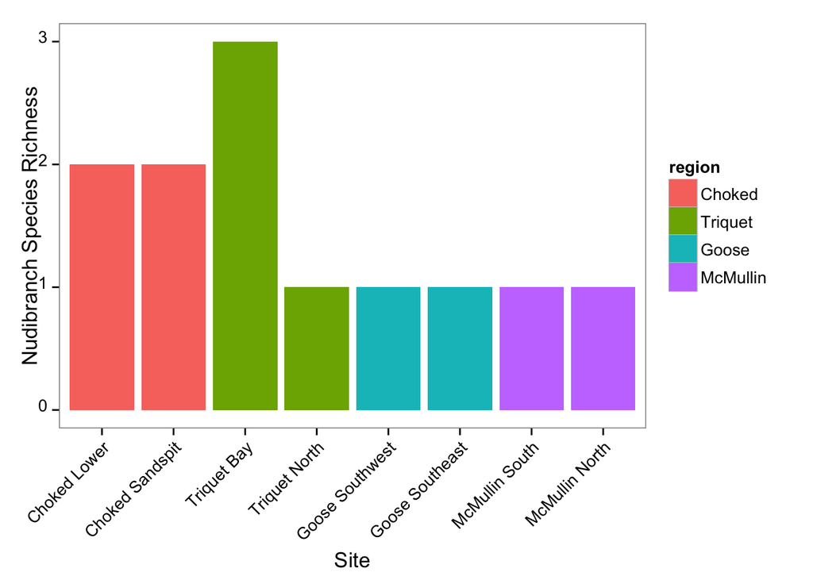

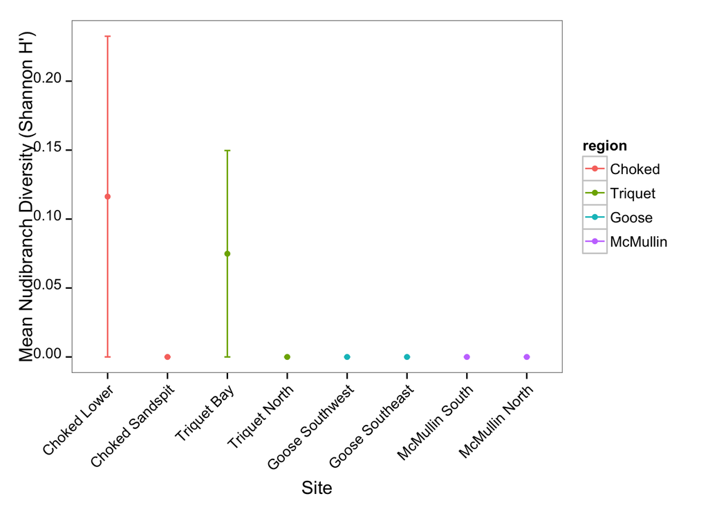

```r
(nudi.figs.site     <- MakeInvertFigures(nudi.summary.site))
```

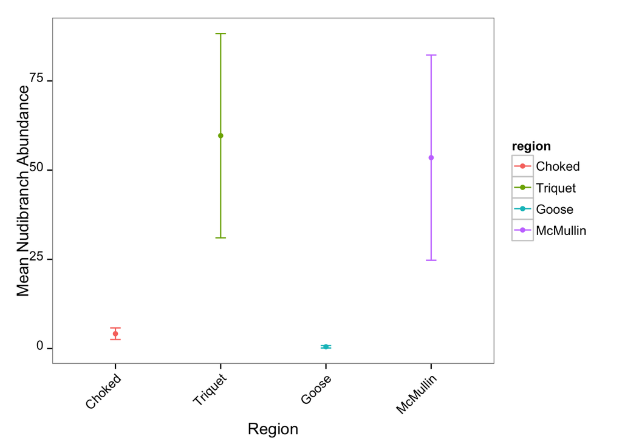

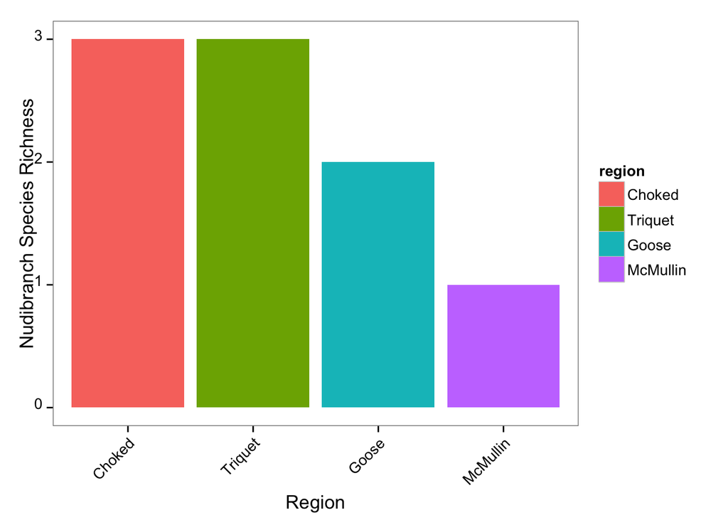

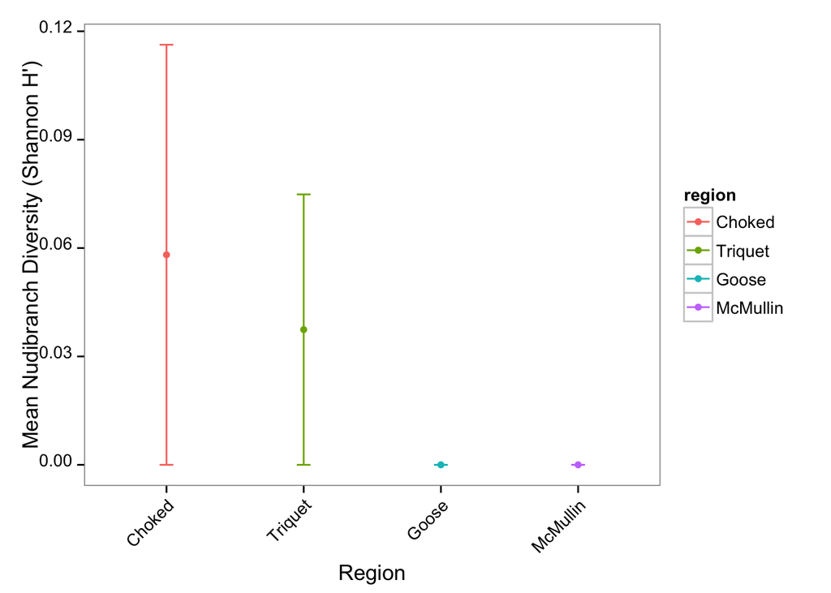

```r
(nudi.figs.region   <- MakeInvertFigures(nudi.summary.region))
```

### Sea stars only

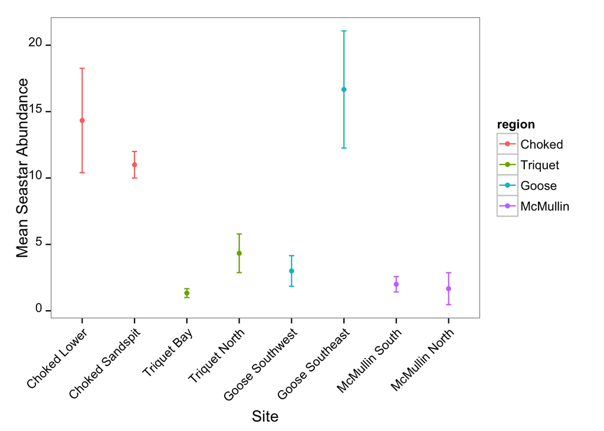

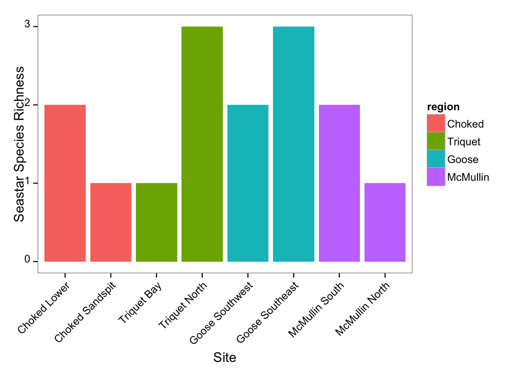

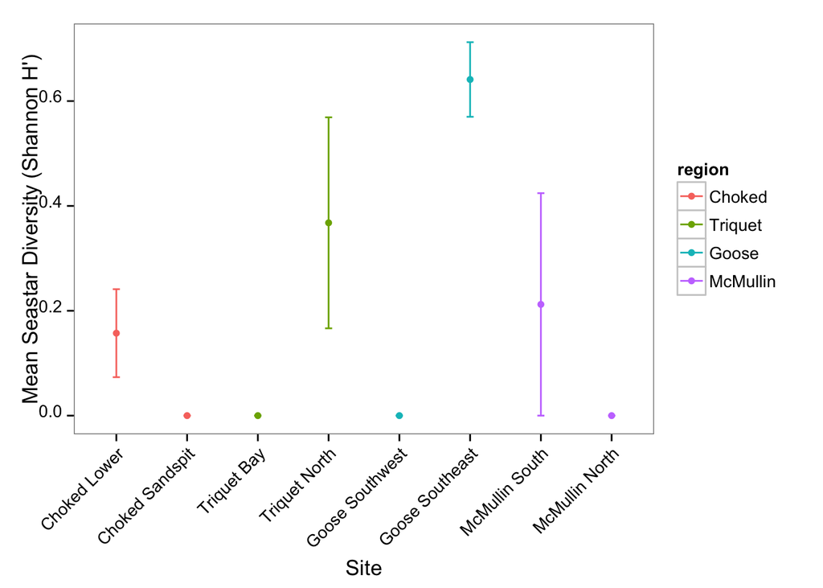

```r
(star.figs.site     <- MakeInvertFigures(star.summary.site))
```

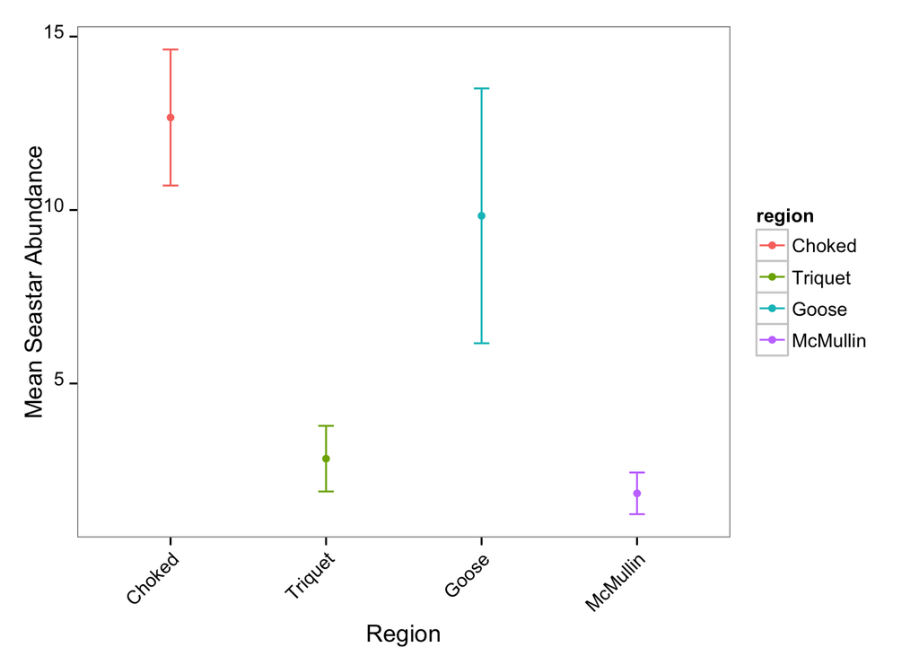

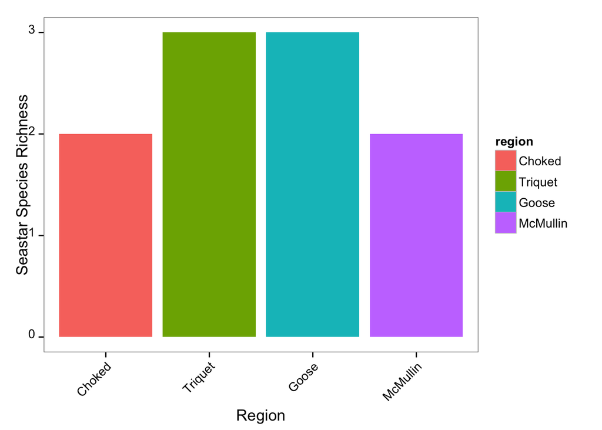

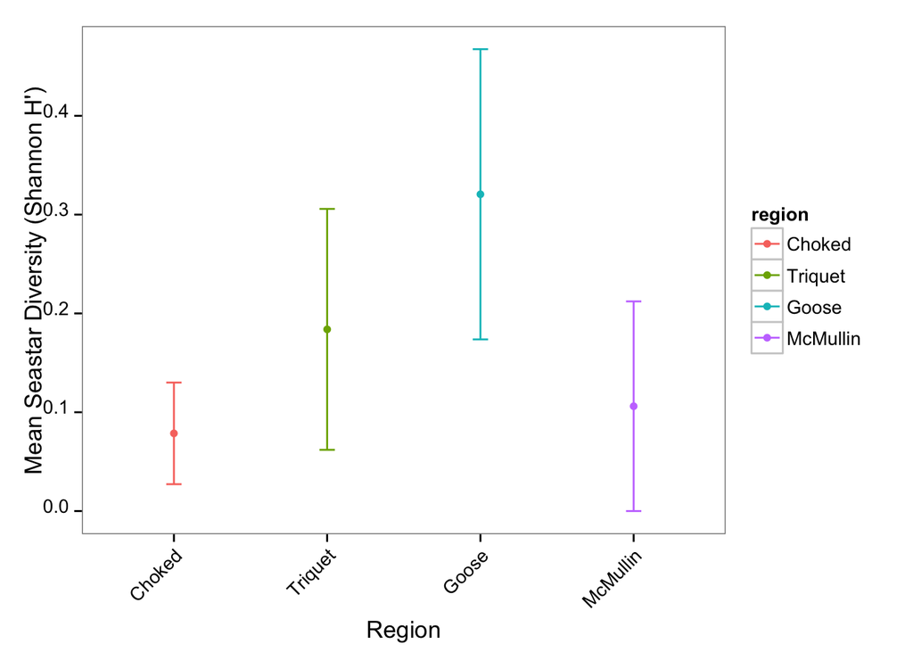

```r
(star.figs.region   <- MakeInvertFigures(star.summary.region))
```

### Various leftovers

```r
# (var.figs.site      <- MakeInvertFigures(var.summary.site))
# (var.figs.region    <- MakeInvertFigures(var.summary.region))
```